# Week 4 Activity - Solutions

**8. Create a histogram of `bill_length_mm`.**

- Does the distribution look symmetric, skewed left, or skewed right?

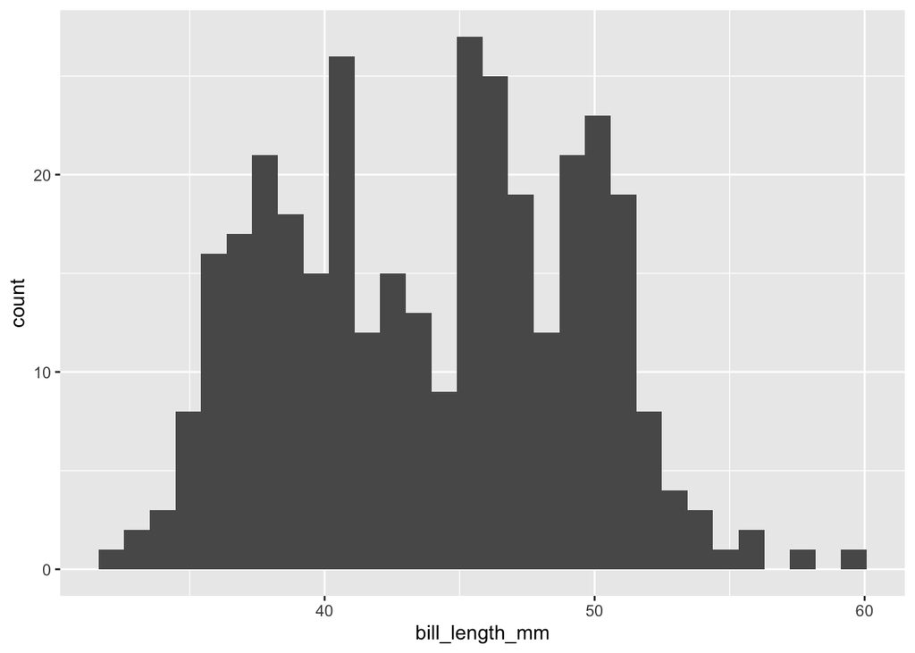

```r
penguins |>
    ggplot(aes(x= bill_length_mm)) +
    geom_histogram()
```

*Written answer here:* The distribution is mostly symmetric with an obvious dip in the middle range

**9. Create a density plot of `bill_length_mm`.**

- Use `geom_density()`.
- How does it compare to the histogram?

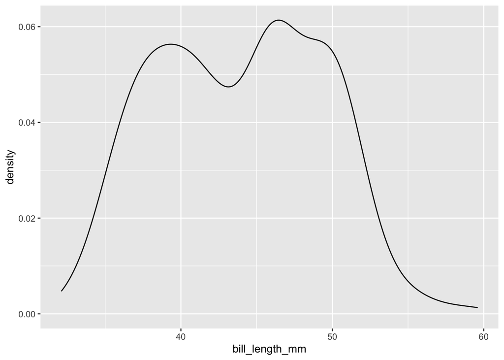

```r
penguins |>
    ggplot(aes(x= bill_length_mm)) +
    geom_density()
```

*Written answer here:* The density plot mostly maintains the same structure, but represents the density through a smooth line rather than through bars

**10. Create a boxplot of `body_mass_g`.**

- Are there potential outliers?

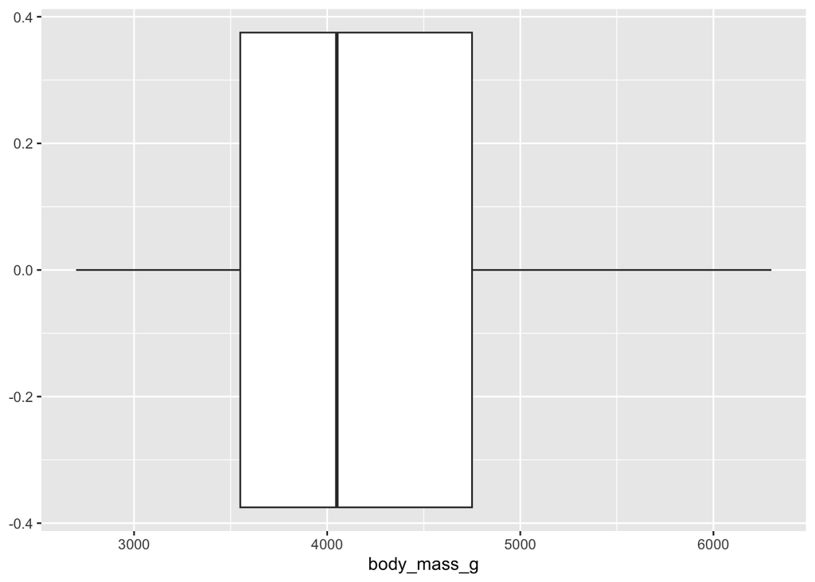

```r
penguins |>
    ggplot(aes(x= body_mass_g)) +
    geom_boxplot()
```

## Part 3: Grouped Summaries + `geom_col()`

**11. Count the number of penguins in each species using `count()`. Store the result.**

```r
species_count <- penguins |>
  group_by(species) |>
  summarize(count = n())
# Adelie has most penguins
```

**12. Use `geom_col()` to recreate the species counts.**

- Why must we use `geom_col()` instead of `geom_bar()` here?

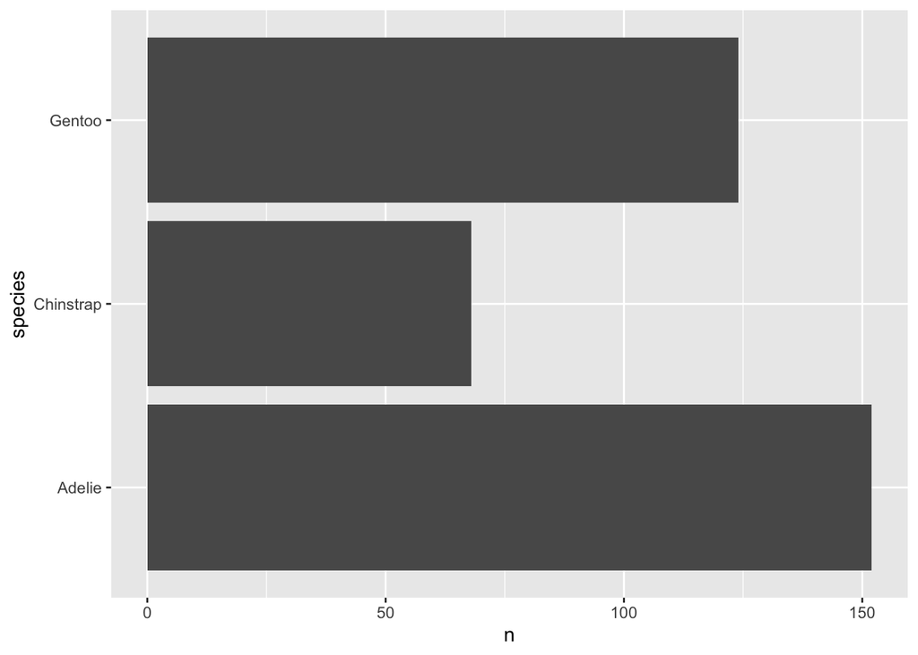

```r
penguins |>
    count(species) |>
    ggplot(aes(y = species, x = n)) +
    geom_col()
```

*Written answer here:* We must use geom col because it is able to draw up the lines to a pre-defined count, whereas using geom_bar is used for raw data. ggplot would try to count the rows of the summarized data, which would give each species a count of 1 (because each appears once after count()).

**13. Count the number of penguins by `species` and `island`.**

- Which combination is most common?

```r
penguins |>
  count(species, island) |>
  arrange(desc(n))
```

```
# A tibble: 5 × 3
  species   island        n
  <fct>     <fct>     <int>
1 Gentoo    Biscoe      124
2 Chinstrap Dream        68
3 Adelie    Dream        56
4 Adelie    Torgersen    52
5 Adelie    Biscoe       44
```

*Written answer here:* The most common combination is Gentoo penguins on Biscoe Island

## Part 4: Two Variable Relationships

**14. Create a scatterplot of:**

- `bill_length_mm` (x)
- `flipper_length_mm` (y)
- What kind of relationship do you see?

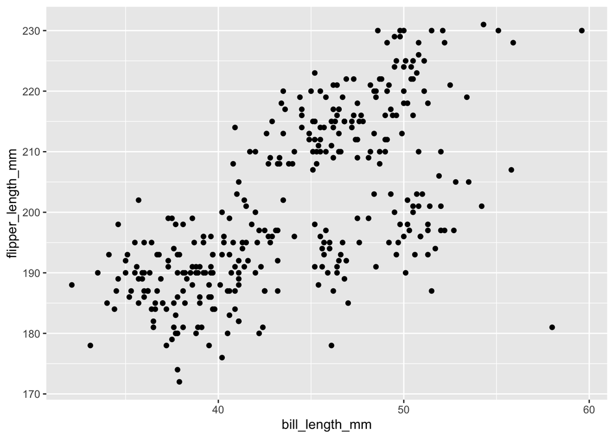

```r
penguins |>
  ggplot(aes(x = bill_length_mm, y = flipper_length_mm)) +
  geom_point()
```

*Written answer here:* It looks like, as bill length increases, so does flipper length. There is a positive correlation between the two variables.

**15. Modify the scatterplot:**

- Add `color = species`.
- Does separating by species clarify the relationship?

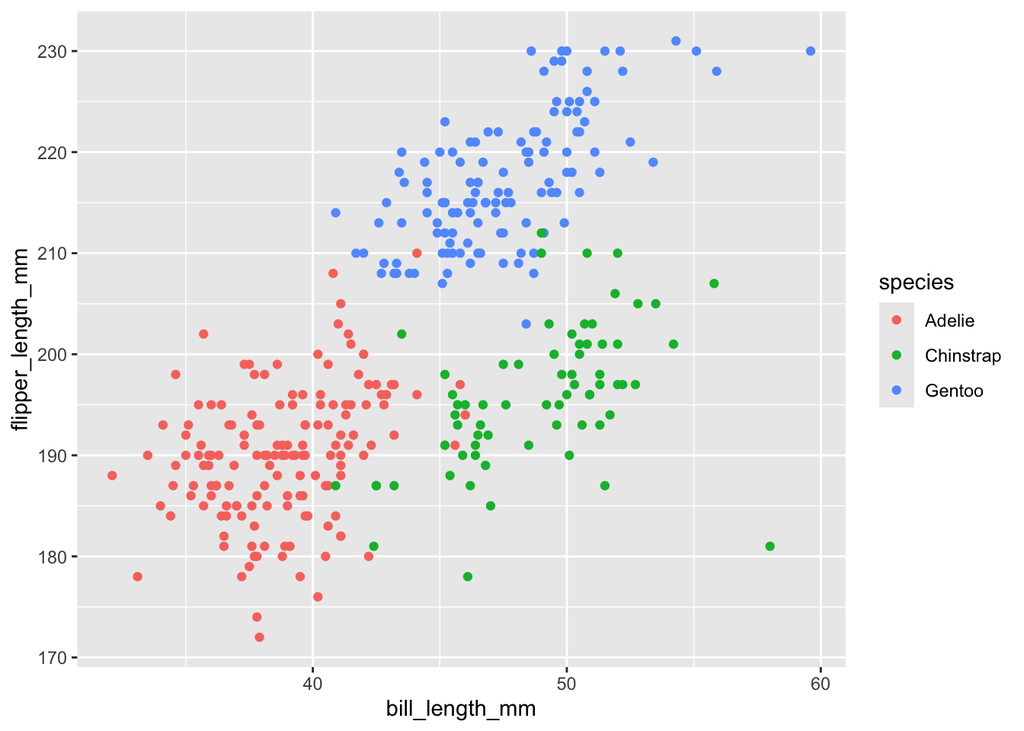

```r
penguins |>
  ggplot(aes(x = bill_length_mm,
             y = flipper_length_mm,
             color = species)) +
  geom_point()
```

*Written answer here:* Yes, it makes the relationship very clear now because it separates the clouds of points. It becomes very obvious that the species that the penguin is has some sort of impact or causal effect on the flipper and bill length.

**16. Change the same scatterplot to:**

- `shape = species` instead of color.
- When might shape be preferable to color?

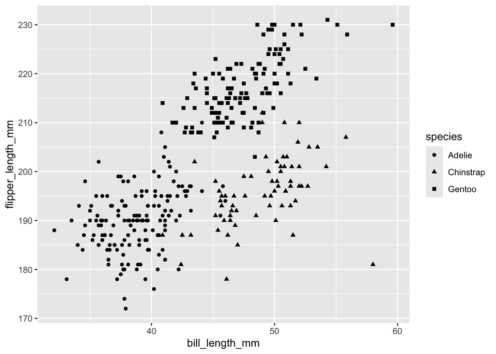

```r
penguins |>
  ggplot(aes(x = bill_length_mm,
             y = flipper_length_mm,
             shape = species)) +
  geom_point()
```

*Written answer here:* Shape might be preferable to color in black-white printing, if someone is color blind, if you want to use color for another variable (like sex), etc

**17. Create a boxplot of: `body_mass_g` by species.**

- Which species tends to be heaviest?

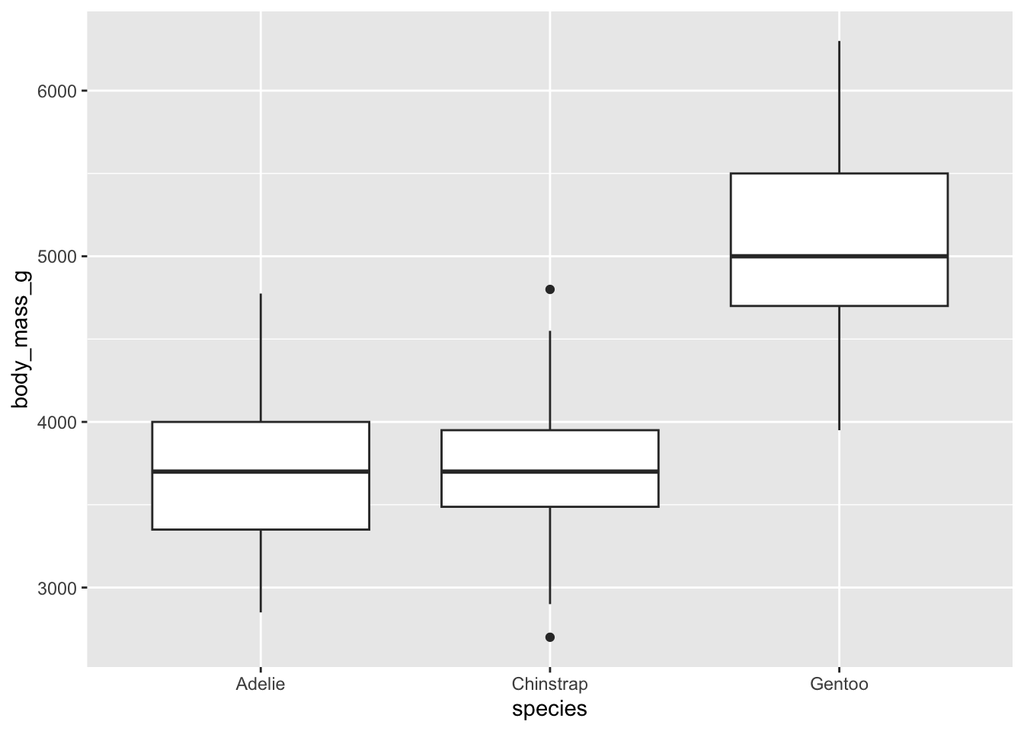

```r
penguins |>
  ggplot(aes(x = species, y = body_mass_g)) +
  geom_boxplot()
```

*Written answer here:* Gentoo tends to be heaviest.

## Part 5: Reflection (Short Discussion)

**18. What is the difference between geom_bar() and geom_col()?**

*Written answer here:* Geom_bar is for when raw data needs summarizing because the default is count, whereas col is better for pre-summarized data.

**19. What is the unit of observation in:**

- penguins?
- mtcars?

*Written answer here:* In penguins, each row is a penguin on the island. In mtcars, each row is a car model from a specific brand.

**20. Which plots felt more exploratory vs explanatory?**

*Written answer here:* up to interpretation, but generally plots where we summarize or highlight a message are explanatory, while plots that let us probe and investigate patterns are exploratory. 15, 16, 17 are examples of explanatory charts, and 6-10 are examples of exploratory plots.

**21. Next level**

Let’s practice making some graphs with `ggplot2`!

1. Load the `mpg` dataset (which is inside tidyverse package).

```r
mpg
```

```
# A tibble: 234 × 11
   manufacturer model      displ  year   cyl trans drv     cty   hwy fl    class
   <chr>        <chr>      <dbl> <int> <int> <chr> <chr> <int> <int> <chr> <chr>
 1 audi         a4           1.8  1999     4 auto… f        18    29 p     comp…
 2 audi         a4           1.8  1999     4 manu… f        21    29 p     comp…
 3 audi         a4           2    2008     4 manu… f        20    31 p     comp…
 4 audi         a4           2    2008     4 auto… f        21    30 p     comp…
 5 audi         a4           2.8  1999     6 auto… f        16    26 p     comp…
 6 audi         a4           2.8  1999     6 manu… f        18    26 p     comp…
 7 audi         a4           3.1  2008     6 auto… f        18    27 p     comp…
 8 audi         a4 quattro   1.8  1999     4 manu… 4        18    26 p     comp…
 9 audi         a4 quattro   1.8  1999     4 auto… 4        16    25 p     comp…
10 audi         a4 quattro   2    2008     4 manu… 4        20    28 p     comp…
# ℹ 224 more rows
```

2. Take a look at the data: what is easy column representing? What does each row represent? *(Hint: if you are not sure, type `?mpg` into your console to launch the help panel)*

```r
?mpg
# Each row is a car model
# each column is a parameter about that car
# manufacturer = manufacturer name
# model = model name
# displ = engine displacement, in litres
# year = year of manufacture
# cyl = number of cylinders
# trans = type of transmission
# drv = the type of drive train, where f = front-wheel drive, r = rear wheel drive, 4 = 4wd
# cty = city miles per gallon
# hwy = highway miles per gallon
# fl = fuel type
# class = "type" of car
```

3. Create a scatter plot of `model` vs `cty`, colored by `year`.

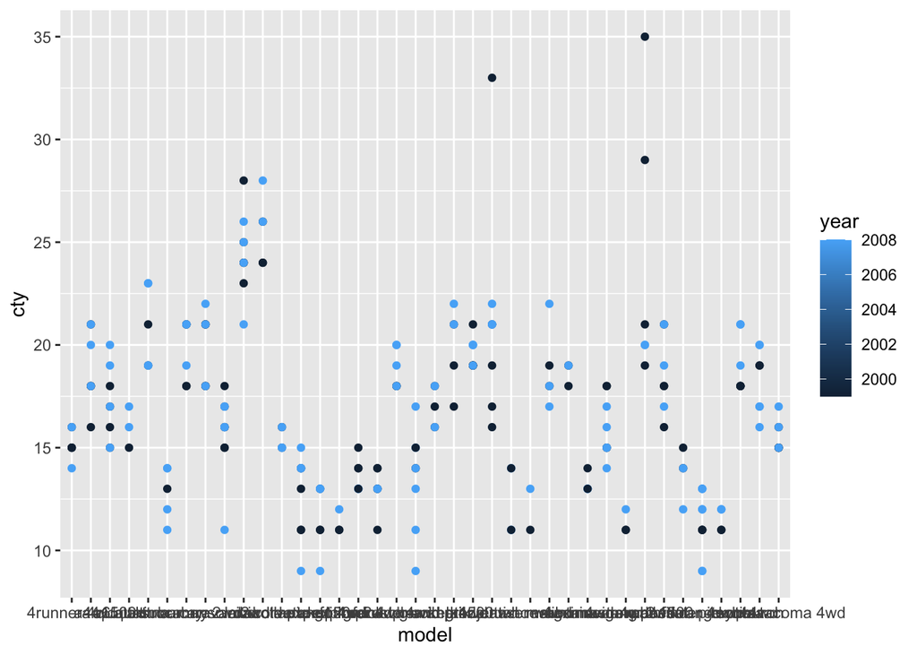

```r
mpg |>
    ggplot(aes(x = model, y = cty, color = year)) +
    geom_point()
```

4. Experiment with different `geom_()` functions to visualize the data

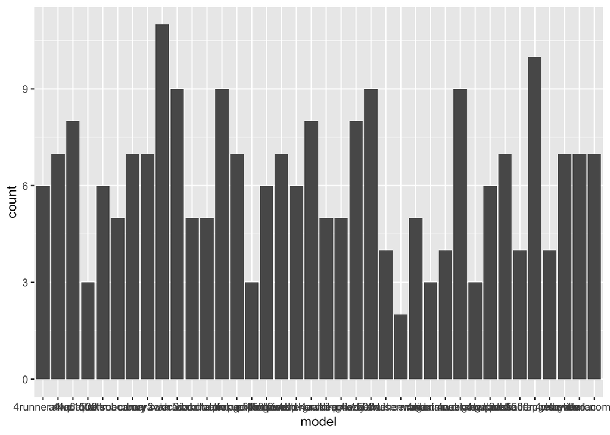

```r
mpg |>
    ggplot(aes(x = model, color = year)) +
    geom_bar()
```

5. Customize your plots with themes and labels.

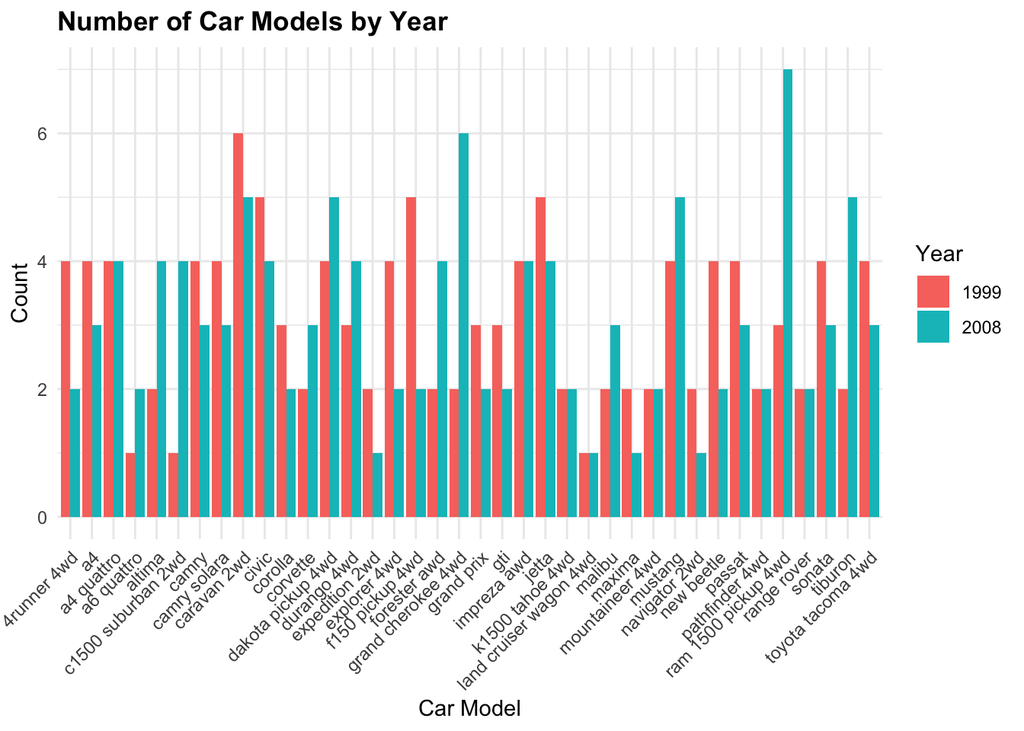

```r
mpg |>
  ggplot(aes(x = model, fill = factor(year))) +
  geom_bar(position = "dodge") +
  labs(
    title = "Number of Car Models by Year",
    x = "Car Model",
    y = "Count",
    fill = "Year"
  ) +
  theme_minimal() +
  theme(
    axis.text.x = element_text(angle = 45, hjust = 1),
    plot.title = element_text(face = "bold")
  )
```